# ClustAsess tutorial

*2024-11-04*

# Chapter 1 ClustAssess: Tools for Assessing Clustering

Single cell clustering experiments are known to produce highly variable results, largely influenced by the choice of algorithm and parameters used for implementation. To address these challenges, we introduce ClustAssess, an R package that integrates various tools in an intuitive, robust, and reproducible manner. ClustAssess provides a unified object that can be utilized to launch a user-friendly shiny app for easy visualization of the results. Within the app, researchers can explore a wide range of algorithms and parameters for dimensionality reduction, graph construction, and graph clustering, enabling them to identify the optimal configuration for their specific study. Additionally, the app enables users to investigate gene expression across one or multiple genes, compare it to metadata features, and conduct cross-comparisons of different configurations. Researchers can also identify differentially expressed genes across clusters and enriched pathways.

These preprocessing steps will create a stable clustering that can be used downstream to calculate pseudotime, RNA-velocity, as well as GRN inference or cell to cell communication.

A working example of the app can be found here: https://mohorianulab.org/shiny/ClustAssess/clustassess_immune/

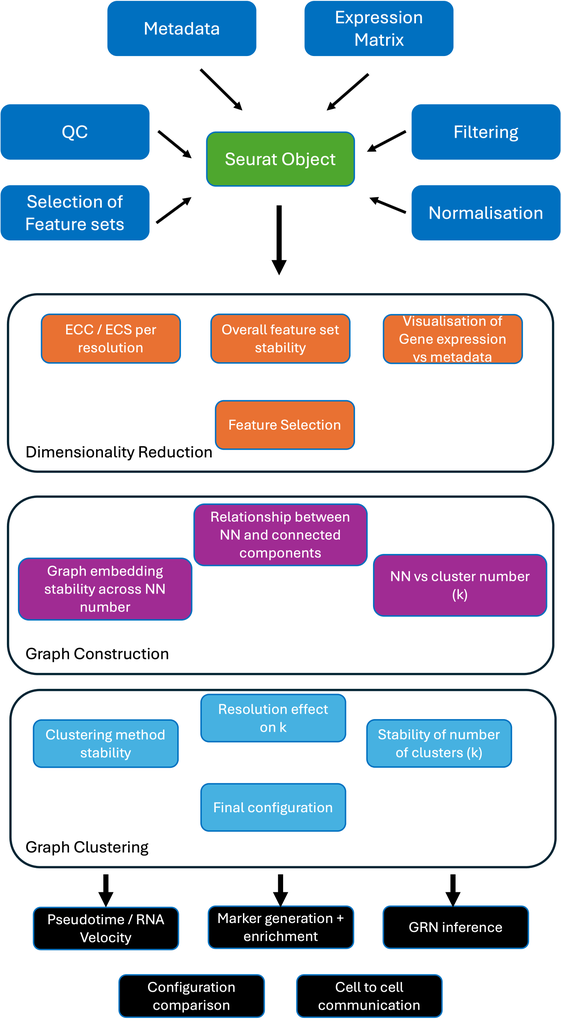

Figure 1.1: Flowchart highlighting the different steps and sections included in the shiny app